# TP : CIFAR 10

Solène Lesage

## Présentation du projet

Nous disposons d'une base de données d'images CIFAR10 et nous souhaitons développer différents modèles de classification basés sur des modèles de réseaux de neurones convolutionnel afin de trouver un meilleur modèle suivant un choix d'hyperparamètres bien définis. Le modèle choisi pourra alors être utilisé pour faire des prédictions sur de nouvelles images.

Pour évaluer les performances des modèles testés, nous allons nous appuyer sur les courbes effectuées sur le jeu d'entrainement, notamment en regardant la fonction de perte et la métrique accuracy. Nous allons aussi basé notre analyse sur les matrices de confusion obtenues ainsi que sur les performances des modèles.

## Présentation de la base de données CIFAR10

Cette base de données est constituée de 60 000 photos de 32X32 pixels regroupée en 10 classes. Les étiquettes des classes sont les suivantes :

- 0: avion
- 1: automobile
- 2: oiseau
- 3: chat
- 4: cerfs
- 5: chien
- 6: grenouille
- 7: cheval
- 8: bateau
- 9: camion

## Chargement des packages nécessaires

```python
import matplotlib.pyplot as plt
from __future__ import absolute_import, division, print_function, unicode_literals
import tensorflow as tf
from tensorflow import keras

from tensorflow.keras.models import Sequential # Model type to be used
from tensorflow.keras.layers import Dense, Activation, Dropout # Make Fully connected (FC) layers
from tensorflow.keras.utils import to_categorical # NumPy related tools
from tensorflow.keras.callbacks import TensorBoard  #Visulization of Accuracy and loss

from tensorflow.keras.preprocessing.image import ImageDataGenerator
from tensorflow.keras.layers import Conv2D, MaxPooling2D, Flatten

import numpy as np
import matplotlib.pyplot as plt
import random                        # for generating random numbers

from skimage import color, io
```

## Chargement du jeu de données CIFAR 10

```python
from keras.datasets import cifar10
(X_train, y_train), (X_val, y_val) = cifar10.load_data()
```

```
Downloading data from https://www.cs.toronto.edu/~kriz/cifar-10-python.tar.gz
```

```python
print('Train: X = %s, y =% s' % (X_train.shape, y_train.shape))
print('Validation: X = %s, y = %s' % (X_val.shape, y_val.shape))
```

```
Train: X = (50000, 32, 32, 3), y =(50000, 1)
Validation: X = (10000, 32, 32, 3), y = (10000, 1)
```

Après avoir chargé les données, nous pouvons voir qu'il y a 50 000 images dans le jeu de données d'entraînement et 10 000 dans celui de validation. Ces images sont bien de dimensions 32 x 32 pixels et en couleurs car il y a trois canaux.

```python
# Conversion des images en niveau de gris
X_train_grey = color.rgb2gray(X_train)
X_val_grey = color.rgb2gray(X_val)
```

## Visualisation aléatoire des images pour chaque classe

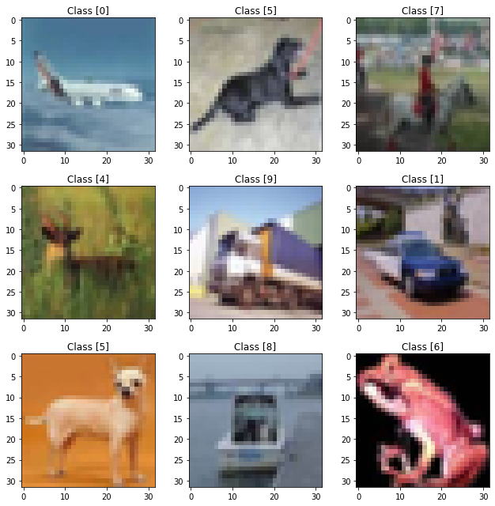

```python
plt.rcParams['figure.figsize'] = (9,9)

for i in range(9):
    plt.subplot(3,3,i+1)
    num = random.randint(0, len(X_train))
    plt.imshow(X_train[num], cmap='gray', interpolation='none')
    plt.title("Class {}".format(y_train[num]))

plt.tight_layout()
```

On observe que certaines de ces images sont de faibles résolutions et parfois difficiles à reconnaitre à l'oeil nu. Il est donc important de trouver et d'utiliser des algorithmes performants comme les réseaux de neurones convolutifs pour pouvoir être en mesure de classer ces images.

On travaillera aussi avec les images en niveau de gris dont on peut représenter quelques images ci-dessous.

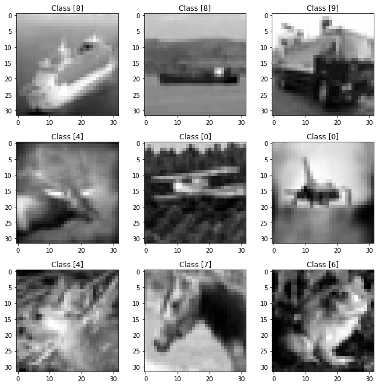

```python
plt.rcParams['figure.figsize'] = (9,9)
for i in range(9):
    plt.subplot(3,3,i+1)
    num = random.randint(0, len(X_train_grey))
    plt.imshow(X_train_grey[num], cmap='gray', interpolation='none')
    plt.title("Class {}".format(y_train[num]))

plt.tight_layout()
```

## Préparation des données

```python
# Redimentionner les images + Convertion des entiers en décimaux
X_train = np.reshape(X_train,(50000,3072)).astype('float32')
X_val = np.reshape(X_val,(10000,3072)).astype('float32')

X_train_grey = np.reshape(X_train_grey,(50000,1024)).astype('float32')
X_val_grey = np.reshape(X_val_grey,(10000,1024)).astype('float32')

# Normaliser les entrées (convertir de 0-255 en 0-1)
X_train /= 255
X_val /= 255

X_train_grey /= 255
X_val_grey /= 255
```

```python
# Encodage des sorties des échantillons de données (train et validation) One Hot Encoding
Y_train = to_categorical(y_train, num_classes=10)
Y_val = to_categorical(y_val, num_classes=10)
```

# Fully connected + Niveau de gris

## Premier modèle : Fully connected (1 seule couche) + Image en niveau de gris

On commence par définir un premier modèle Fully-connected avec une seule couche (la couche de sortie) constituée de 10 neurones (car il y a 10 classes à prédire en sortie).

On commencera par travailler dans un premier temps avec les images en noir et blanc.

```python
# Définition du modèle
model = Sequential([
    Dense(10),
    Activation('softmax'),
])
```

Après avoir défini le modèle, on va chercher à l'évaluer en spécifiant une fonction de perte et l'optimiseur.

La fonction de perte que nous utiliserons est l'entropie croisée pour la classification.

Les prédictions que nous obtiendrons en sortie seront les probabilités d'appartenir à une des 10 classes.

```python
# Compilation du modèle
model.compile(loss='categorical_crossentropy',
              optimizer='adam',
              metrics=['accuracy'])
```

```python
history = model.fit(
          X_train_grey, Y_train,
          validation_data=(X_val_grey, Y_val),
          epochs=20, batch_size=32,
          verbose=1)
```

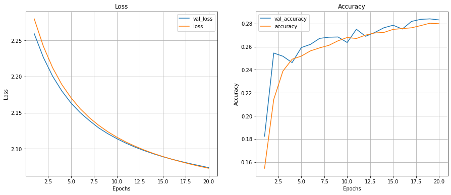

```python
epochs = range(1, len(history.history['val_loss'])+1)
plt.figure(figsize=(15,6))
plt.subplot(121)
plt.title('Loss')
plt.plot(epochs, history.history['val_loss'], label='val_loss')
plt.plot(epochs, history.history['loss'], label='loss')
plt.xlabel('Epochs')
plt.ylabel('Loss')
#plt.ylim([0.5,1.5])
plt.grid()
plt.legend()
plt.subplot(122)
plt.title('Accuracy')
plt.plot(epochs, history.history['val_accuracy'], label='val_accuracy')
plt.plot(epochs, history.history['accuracy'], label='accuracy')
plt.xlabel('Epochs')
plt.ylabel('Accuracy')
#plt.ylim([0,1])
plt.grid()
plt.legend()
plt.show()
```

Les résultats obtenus ne sont pas performants. Le modèle manque clairement de précision. En effet, les erreurs de la loss décroissent bien quand le nombre d'epochs augmente et pareil, le score d'accuracy augmente quand le nombre d'epochs augmente.

En revanche, les courbes obtenues sont plutot stables.

On pourra par la suite essayer d'augmenter le nombre d'epochs, le batch_size pour voir s'il y a une amélioration sur la convergence, les scores et la stabilité des résultats.

Pour évaluer le modèle, le dataset de validation doit être différent de celui du data test. Mais dans ce TP, on évalue le modèle sur le dataset de validation.

```python
# Evaluation du modèle
score = model.evaluate(X_val_grey, Y_val, verbose=1)
print('Test score: %.3f' % score[0])
print('Test accuracy: %.3f' % score[1])
```

```
Test score: 2.074
Test accuracy: 0.283
```

## Deuxième modèle : Fully connected + 1 couche + Ajustement du batch_size (Images en niveau de gris)

On va maintenant s'intéresser au paramètre batch_size.

### Avec un batch_size = 10

```python
# Définition du modèle
model = Sequential([
    Dense(10),
    Activation('softmax'),
])
```

```python
# Compilation du modèle
model.compile(loss='categorical_crossentropy',
              optimizer='adam',
              metrics=['accuracy'])
```

```python
history = model.fit(
          X_train_grey, Y_train,
          validation_data=(X_val_grey, Y_val),
          epochs=20, batch_size=10,
          verbose=1)
```

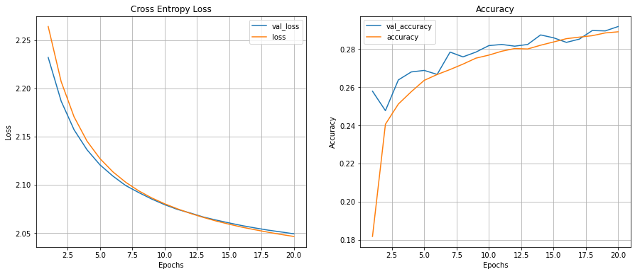

```python
epochs = range(1, len(history.history['val_loss'])+1)
plt.figure(figsize=(15,6))
plt.subplot(121)
plt.title('Cross Entropy Loss')
plt.plot(epochs, history.history['val_loss'], label='val_loss')
plt.plot(epochs, history.history['loss'], label='loss')
plt.xlabel('Epochs')
plt.ylabel('Loss')
#plt.ylim([0.5,1.5])
plt.grid()
plt.legend()
plt.subplot(122)
plt.title('Accuracy')
plt.plot(epochs, history.history['val_accuracy'], label='val_accuracy')
plt.plot(epochs, history.history['accuracy'], label='accuracy')
plt.xlabel('Epochs')
plt.ylabel('Accuracy')
#plt.ylim([0,1])
plt.grid()
plt.legend()
plt.show()
```

Les scores obtenus sont meilleurs que le premier modèle mais la stabilité peut-être augmenté. Un batch_size plus élevé est préférable.

```python
# Evaluation du modèle sur le data test
score = model.evaluate(X_val_grey, Y_val)
print('Test score: %.3f' % score[0])
print('Test accuracy: %.3f' % score[1])
```

```
Test score: 2.049
Test accuracy: 0.292
```

Les scores obtenus sont légèrement meilleurs que précédemment, on a toujours la stabilité. Mais, on remarque que la courbe tend à descendre et à monter pour l'accuracy.

Augmenter légèrement le batch_size permet d'obtenir des scores plus stables.

### Avec un batch_size de 64

```python
# Définition du modèle
model = Sequential([
    Dense(10),
    Activation('softmax'),
])
```

```python
# Compilation du modèle
model.compile(loss='categorical_crossentropy',
              optimizer='adam',
              metrics=['accuracy'])
```

```python
history = model.fit(
          X_train_grey, Y_train,
          validation_data=(X_val_grey, Y_val),
          epochs=20, batch_size=64,
          verbose=1)
```

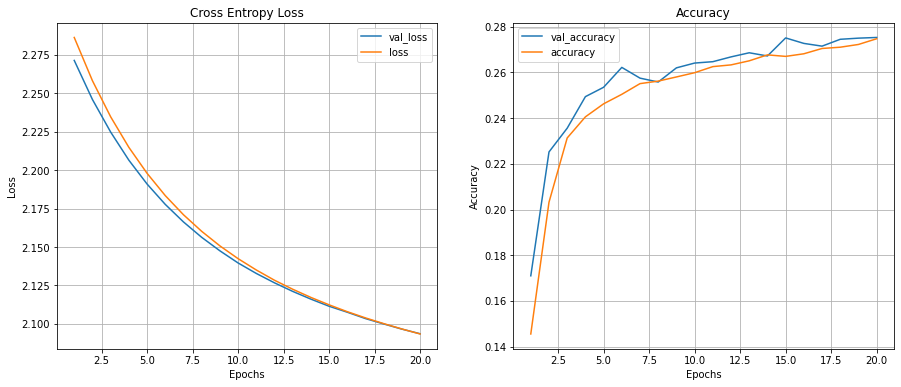

```python
epochs = range(1, len(history.history['val_loss'])+1)
plt.figure(figsize=(15,6))
plt.subplot(121)
plt.title('Cross Entropy Loss')
plt.plot(epochs, history.history['val_loss'], label='val_loss')
plt.plot(epochs, history.history['loss'], label='loss')
plt.xlabel('Epochs')
plt.ylabel('Loss')
#plt.ylim([0.5,1.5])
plt.grid()
plt.legend()
plt.subplot(122)
plt.title('Accuracy')
plt.plot(epochs, history.history['val_accuracy'], label='val_accuracy')
plt.plot(epochs, history.history['accuracy'], label='accuracy')
plt.xlabel('Epochs')
plt.ylabel('Accuracy')
#plt.ylim([0,1])
plt.grid()
plt.legend()
plt.show()
```

```python
# Evaluation du modèle sur le data test
score = model.evaluate(X_val_grey, Y_val)
print('Test score: %.3f' % score[0])
print('Test accuracy: %.3f' % score[1])
```

```
Test score: 2.093
Test accuracy: 0.278
```

On a légérement perdu en précision au niveau des scores comparé aux deux autres modèles.

Le fait d'augmenter le batch_size entraine une augmentation des paramètres et potentiellement un coût élevé pour la RAM, mais, on a observé une nette rapidité dans l'éxécution.

On préférera utiliser un batch_size de 32 qui semble un bon compromis.

## Troisième modèle : Fully connected + 1 couche + Augmentation du nombre d'epochs (Images en niveau de gris)

On va maintenant s'intéresser au nombre d'epochs.

### Avec un nombre epochs = 15

```python
# Définition du modèle
model = Sequential([
    Dense(10),
    Activation('softmax'),
])
```

```python
# Compilation du modèle
model.compile(loss='categorical_crossentropy',
              optimizer='adam',
              metrics=['accuracy'])
```

```python
history = model.fit(
          X_train_grey, Y_train,
          validation_data=(X_val_grey, Y_val),
          epochs=15, batch_size=32,
          verbose=1)
```

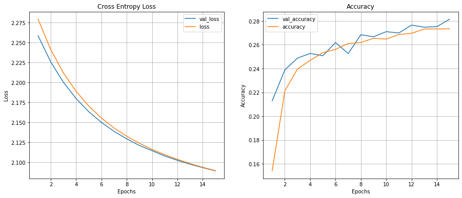

```python
epochs = range(1, len(history.history['val_loss'])+1)
plt.figure(figsize=(15,6))
plt.subplot(121)
plt.title('Cross Entropy Loss')
plt.plot(epochs, history.history['val_loss'], label='val_loss')
plt.plot(epochs, history.history['loss'], label='loss')
plt.xlabel('Epochs')
plt.ylabel('Loss')
#plt.ylim([0.5,1.5])
plt.grid()
plt.legend()
plt.subplot(122)
plt.title('Accuracy')
plt.plot(epochs, history.history['val_accuracy'], label='val_accuracy')
plt.plot(epochs, history.history['accuracy'], label='accuracy')
plt.xlabel('Epochs')
plt.ylabel('Accuracy')
#plt.ylim([0,1])
plt.grid()
plt.legend()
plt.show()
```

```python
# Evaluation du modèle sur le data test
score = model.evaluate(X_val_grey, Y_val)
print('Test score: %.3f' % score[0])
print('Test accuracy: %.3f' % score[1])
```

```
Test score: 2.089
Test accuracy: 0.282
```

Les scores sont bons comparé aux autres modèles, la stabilité peut-être amélioré.

### Avec un nombre epochs=40

```python
# Définition du modèle
model = Sequential([
    Dense(10),
    Activation('softmax'),
])
```

```python
model.compile(loss='categorical_crossentropy',
              optimizer='adam',
              metrics=['accuracy'])
```

```python
history = model.fit(
          X_train_grey, Y_train,
          validation_data=(X_val_grey, Y_val),
          epochs=40, batch_size=32,
          verbose=1)
```

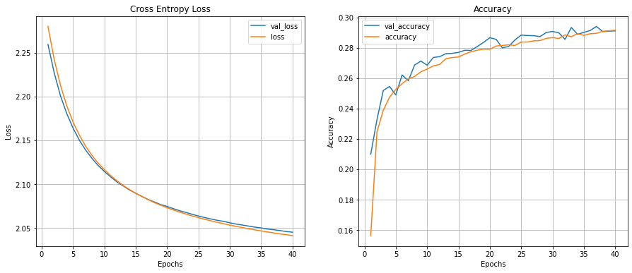

```python
epochs = range(1, len(history.history['val_loss'])+1)
plt.figure(figsize=(15,6))
plt.subplot(121)
plt.title('Cross Entropy Loss')
plt.plot(epochs, history.history['val_loss'], label='val_loss')
plt.plot(epochs, history.history['loss'], label='loss')
plt.xlabel('Epochs')
plt.ylabel('Loss')
#plt.ylim([0.5,1.5])
plt.grid()
plt.legend()
plt.subplot(122)
plt.title('Accuracy')
plt.plot(epochs, history.history['val_accuracy'], label='val_accuracy')
plt.plot(epochs, history.history['accuracy'], label='accuracy')
plt.xlabel('Epochs')
plt.ylabel('Accuracy')
#plt.ylim([0,1])
plt.grid()
plt.legend()
plt.show()
```

```python
# Evaluation du modèle sur le data test
score = model.evaluate(X_val_grey, Y_val)
print('Test score: %.3f' % score[0])
print('Test accuracy: %.3f' % score[1])
```

```
Test score: 2.045
Test accuracy: 0.291
```

On remarque une légère amélioration pour les deux scores (loss et accuracy) quand on augmente le nombre d'epochs mais on perd un peu en stabilité localement. Un nombre de batch_size plus grand peut peut-être amélioré.

Un nombre d'epochs supérieure à 20 semble nous donner de meilleurs résultats.

### Avec un epochs=40 et batch_size=64

```python
# Définition du modèle
model = Sequential([
    Dense(10),
    Activation('softmax'),
])
```

```python
model.compile(loss='categorical_crossentropy',
              optimizer='adam',
              metrics=['accuracy'])
```

```python
history = model.fit(
          X_train_grey, Y_train,
          validation_data=(X_val_grey, Y_val),
          epochs=40, batch_size=64,
          verbose=1)
```

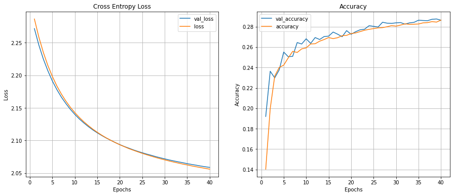

```python
epochs = range(1, len(history.history['val_loss'])+1)
plt.figure(figsize=(15,6))
plt.subplot(121)
plt.title('Cross Entropy Loss')
plt.plot(epochs, history.history['val_loss'], label='val_loss')
plt.plot(epochs, history.history['loss'], label='loss')
plt.xlabel('Epochs')
plt.ylabel('Loss')
#plt.ylim([0.5,1.5])
plt.grid()
plt.legend()
plt.subplot(122)
plt.title('Accuracy')
plt.plot(epochs, history.history['val_accuracy'], label='val_accuracy')
plt.plot(epochs, history.history['accuracy'], label='accuracy')
plt.xlabel('Epochs')
plt.ylabel('Accuracy')
#plt.ylim([0,1])
plt.grid()
plt.legend()
plt.show()
```

```python
# Evaluation du modèle sur le data test
score = model.evaluate(X_val_grey, Y_val)
print('Test score: %.3f' % score[0])
print('Test accuracy: %.3f' % score[1])
```

```
Test score: 2.059
Test accuracy: 0.286
```

Les courbes sont plus stables que le modèle précédent en augmentant le batch_size. Les scores sont légèrement moins bons. On retiendra que le batch_size permet d'obtenir une convergence plus fine.

## Quatrième modèle : Fully-connected + Augmentation des couches dans le réseau

On va ajouter 3 couches dans notre modèle et utiliser le DroupOut pour réduire le sur-apprentissage.

```python
# Ajoute des couches de Dropout pour protéger le modèle du sur-apprentissage sur le data train
Pkeep=0.25
modelDeepFC = Sequential([
    Dense(256, input_shape=(1024,)),
    Activation('relu'),

    Dropout(Pkeep),

    Dense(128),
    Activation('relu'),

    Dropout(Pkeep),

    Dense(10),
    Activation('softmax'),
])
```

```python
# Ajout d'un learning_rate
opt = tf.keras.optimizers.Adam(learning_rate=0.001)

modelDeepFC.compile(loss='categorical_crossentropy',
              optimizer=opt,
              metrics=['accuracy'])

history = modelDeepFC.fit(X_train_grey, Y_train,
          validation_data=(X_val_grey, Y_val),
          epochs=20, batch_size=32,
          verbose=1)
```

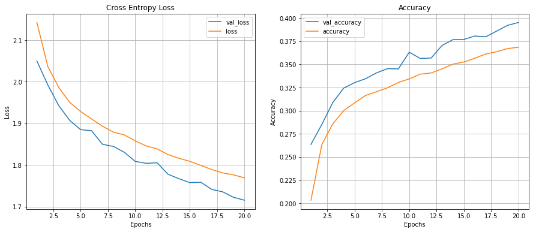

```python
epochs = range(1, len(history.history['val_loss'])+1)
plt.figure(figsize=(15,6))
plt.subplot(121)
plt.title('Cross Entropy Loss')
plt.plot(epochs, history.history['val_loss'], label='val_loss')
plt.plot(epochs, history.history['loss'], label='loss')
plt.xlabel('Epochs')
plt.ylabel('Loss')
#plt.ylim([0.5,1.5])
plt.grid()
plt.legend()
plt.subplot(122)
plt.title('Accuracy')
plt.plot(epochs, history.history['val_accuracy'], label='val_accuracy')
plt.plot(epochs, history.history['accuracy'], label='accuracy')
plt.xlabel('Epochs')
plt.ylabel('Accuracy')
#plt.ylim([0,1])
plt.grid()
plt.legend()
plt.show()
```

```python
# Evaluation du modèle sur le data test
score = modelDeepFC.evaluate(X_val_grey, Y_val)
print('Test score: %.3f' % score[0])
print('Test accuracy: %.3f' % score[1])
```

```
Test score: 1.715
Test accuracy: 0.395
```

Les résultats sont meilleurs tant au niveau des scores de loss et d'accuracy. On peut peut-être amélioré la convergence des courbes en augmentant le nombre de epochs et le batch_size.

### Autre modèle : epochs = 40 et batch_size = 64

```python
# Ajoute des couches de Dropout pour protéger le modèle du sur-apprentissage sur le data train
Pkeep=0.25
modelDeepFC = Sequential([
    Dense(256, input_shape=(1024,)),
    Activation('relu'),

    Dropout(Pkeep),

    Dense(128),
    Activation('relu'),

    Dropout(Pkeep),

    Dense(10),
    Activation('softmax'),
])
```

```python
opt = tf.keras.optimizers.Adam(learning_rate=0.001)

modelDeepFC.compile(loss='categorical_crossentropy',
              optimizer=opt,
              metrics=['accuracy'])

history = modelDeepFC.fit(X_train_grey, Y_train,
          validation_data=(X_val_grey, Y_val),
          epochs=40, batch_size=64,
          verbose=1)
```

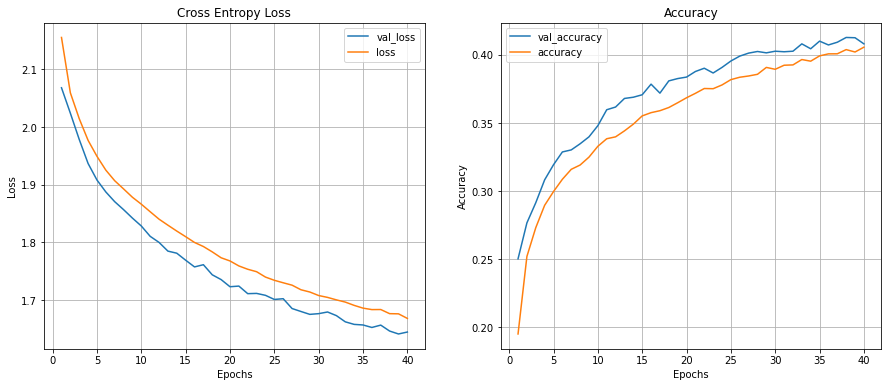

```python
epochs = range(1, len(history.history['val_loss'])+1)
plt.figure(figsize=(15,6))
plt.subplot(121)
plt.title('Cross Entropy Loss')
plt.plot(epochs, history.history['val_loss'], label='val_loss')
plt.plot(epochs, history.history['loss'], label='loss')
plt.xlabel('Epochs')
plt.ylabel('Loss')
#plt.ylim([0.5,1.5])
plt.grid()
plt.legend()
plt.subplot(122)
plt.title('Accuracy')
plt.plot(epochs, history.history['val_accuracy'], label='val_accuracy')
plt.plot(epochs, history.history['accuracy'], label='accuracy')
plt.xlabel('Epochs')
plt.ylabel('Accuracy')
#plt.ylim([0,1])
plt.grid()
plt.legend()
plt.show()
```

```python
# Evaluation du modèle sur le data test
score = modelDeepFC.evaluate(X_val_grey, Y_val)
print('Test score: %.3f' % score[0])
print('Test accuracy: %.3f' % score[1])
```

```
Test score: 1.645
Test accuracy: 0.408
```

Les scores sont meilleurs, la convergence est très bien. On va essayer d'augmenter le nombre d'epochs.

### Autre modèle : epochs = 100 et batch_size = 64

```python
# Ajoute des couches de Dropout pour protéger le modèle du sur-apprentissage sur le data train
Pkeep=0.25
modelDeepFC = Sequential([
    Dense(256, input_shape=(1024,)),
    Activation('relu'),

    Dropout(Pkeep),

    Dense(128),
    Activation('relu'),

    Dropout(Pkeep),

    Dense(10),
    Activation('softmax'),
])
```

```python
opt = tf.keras.optimizers.Adam(learning_rate=0.001)

modelDeepFC.compile(loss='categorical_crossentropy',
              optimizer=opt,
              metrics=['accuracy'])

history = modelDeepFC.fit(X_train_grey, Y_train,
          validation_data=(X_val_grey, Y_val),
          epochs=100, batch_size=64,
          verbose=1)
```

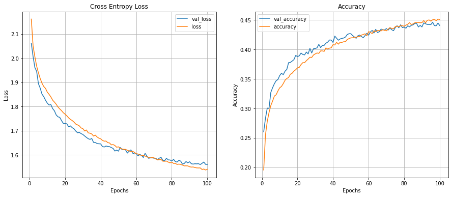

```python
epochs = range(1, len(history.history['val_loss'])+1)
plt.figure(figsize=(15,6))
plt.subplot(121)
plt.title('Cross Entropy Loss')
plt.plot(epochs, history.history['val_loss'], label='val_loss')
plt.plot(epochs, history.history['loss'], label='loss')
plt.xlabel('Epochs')
plt.ylabel('Loss')
#plt.ylim([0.5,1.5])
plt.grid()
plt.legend()
plt.subplot(122)
plt.title('Accuracy')
plt.plot(epochs, history.history['val_accuracy'], label='val_accuracy')
plt.plot(epochs, history.history['accuracy'], label='accuracy')
plt.xlabel('Epochs')
plt.ylabel('Accuracy')
#plt.ylim([0,1])
plt.grid()
plt.legend()
plt.show()
```

```python
# Evaluation du modèle sur le data test
score = modelDeepFC.evaluate(X_val_grey, Y_val)
print('Test score: %.3f' % score[0])
print('Test accuracy: %.3f' % score[1])
```

```
Test score: 1.561
Test accuracy: 0.441
```

Les scores sont meilleurs. En revanche, on observe que la courbe de train augmente, il y a donc du sur-apprentissage donc on peut essayer de diminuer le nombre d'epochs.

### Autre modèle : epochs = 80 et batch_size = 64

```python
# Ajoute des couches de Dropout pour protéger le modèle du sur-apprentissage sur le data train
Pkeep=0.25
modelDeepFC = Sequential([
    Dense(256, input_shape=(1024,)),
    Activation('relu'),

    Dropout(Pkeep),

    Dense(128),
    Activation('relu'),

    Dropout(Pkeep),

    Dense(10),
    Activation('softmax'),
])
```

```python
opt = tf.keras.optimizers.Adam(learning_rate=0.001)

modelDeepFC.compile(loss='categorical_crossentropy',
              optimizer=opt,
              metrics=['accuracy'])

history = modelDeepFC.fit(X_train_grey, Y_train,
          validation_data=(X_val_grey, Y_val),
          epochs=80, batch_size=64,
          verbose=1)
```

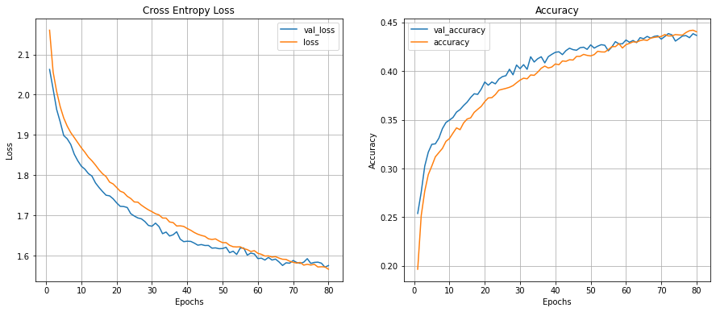

```python
epochs = range(1, len(history.history['val_loss'])+1)
plt.figure(figsize=(15,6))
plt.subplot(121)
plt.title('Cross Entropy Loss')
plt.plot(epochs, history.history['val_loss'], label='val_loss')
plt.plot(epochs, history.history['loss'], label='loss')
plt.xlabel('Epochs')
plt.ylabel('Loss')
#plt.ylim([0.5,1.5])
plt.grid()
plt.legend()
plt.subplot(122)
plt.title('Accuracy')
plt.plot(epochs, history.history['val_accuracy'], label='val_accuracy')
plt.plot(epochs, history.history['accuracy'], label='accuracy')
plt.xlabel('Epochs')
plt.ylabel('Accuracy')
#plt.ylim([0,1])
plt.grid()
plt.legend()
plt.show()
```

```python
# Evaluation du modèle sur le data test
score = modelDeepFC.evaluate(X_val_grey, Y_val)
print('Test score: %.3f' % score[0])
print('Test accuracy: %.3f' % score[1])
```

```
Test score: 1.575
Test accuracy: 0.437
```

### Autre modèle : epochs = 70 et batch_size = 64

```python
# Ajoute des couches de Dropout pour protéger le modèle du sur-apprentissage sur le data train
Pkeep=0.25
modelDeepFC = Sequential([
    Dense(256, input_shape=(1024,)),
    Activation('relu'),

    Dropout(Pkeep),

    Dense(128),
    Activation('relu'),

    Dropout(Pkeep),

    Dense(10),
    Activation('softmax'),
])
```

```python
opt = tf.keras.optimizers.Adam(learning_rate=0.001)

modelDeepFC.compile(loss='categorical_crossentropy',
              optimizer=opt,
              metrics=['accuracy'])

history = modelDeepFC.fit(X_train_grey, Y_train,
          validation_data=(X_val_grey, Y_val),
          epochs=70, batch_size=64,
          verbose=1)
```

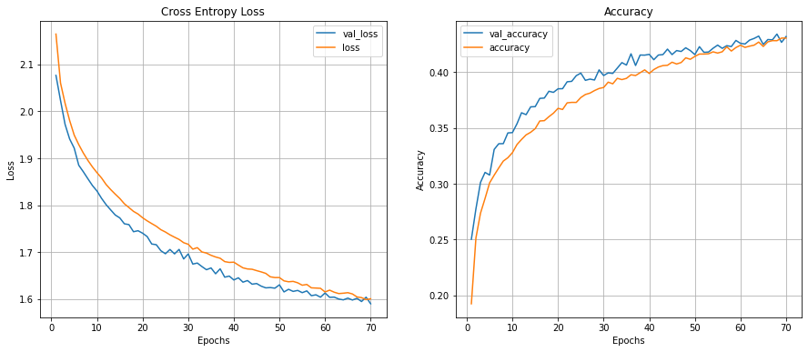

```python
epochs = range(1, len(history.history['val_loss'])+1)
plt.figure(figsize=(15,6))
plt.subplot(121)
plt.title('Cross Entropy Loss')
plt.plot(epochs, history.history['val_loss'], label='val_loss')
plt.plot(epochs, history.history['loss'], label='loss')
plt.xlabel('Epochs')
plt.ylabel('Loss')
#plt.ylim([0.5,1.5])
plt.grid()
plt.legend()
plt.subplot(122)
plt.title('Accuracy')
plt.plot(epochs, history.history['val_accuracy'], label='val_accuracy')
plt.plot(epochs, history.history['accuracy'], label='accuracy')
plt.xlabel('Epochs')
plt.ylabel('Accuracy')
#plt.ylim([0,1])
plt.grid()
plt.legend()
plt.show()
```

```python
# Evaluation du modèle sur le data test
score = modelDeepFC.evaluate(X_val_grey, Y_val)
print('Test score: %.3f' % score[0])
print('Test accuracy: %.3f' % score[1])
```

```
Test score: 1.590
Test accuracy: 0.432
```

### Prédiction

```python
predict_x=modelDeepFC.predict(X_val_grey)
predicted_classes=np.argmax(predict_x,axis=1)

correct_indices = np.nonzero(predicted_classes == y_val)[0]

incorrect_indices = np.nonzero(predicted_classes != y_val)[0]
```

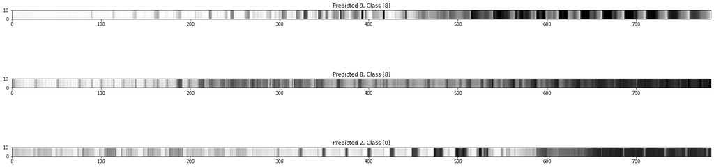

```python
plt.figure(figsize=(32,8))
for i in range(1,4):
  plt.subplot(3,1,i)
  plt.imshow(X_val_grey[i].reshape(1,32**2), cmap='gray', interpolation='none', extent=[0,32**2,0,10])
  plt.title("Predicted {}, Class {}".format(predicted_classes[i], y_val[i]))
plt.show()
```

[figure not shown]

```python
plt.figure()
for i, correct in enumerate(correct_indices[:6]):
    plt.subplot(3,3,i+1)
    plt.imshow(X_val_grey[correct].reshape(32,32), cmap='gray', interpolation='none')
    plt.title("Predicted {}, Class {}".format(predicted_classes[correct], y_val[correct]))

plt.tight_layout()
```

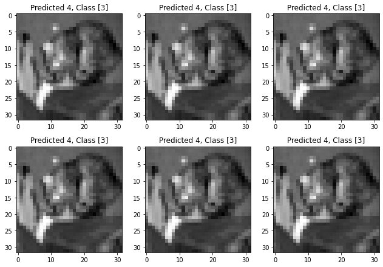

```python
plt.figure()
for i, incorrect in enumerate(incorrect_indices[:6]):
    plt.subplot(3,3,i+1)
    plt.imshow(X_val_grey[incorrect].reshape(32,32), cmap='gray', interpolation='none')
    plt.title("Predicted {}, Class {}".format(predicted_classes[incorrect], y_val[incorrect]))

plt.tight_layout()
```

# Fully connected + RGB

## Premier modèle : Fully connected (1 seule couche) + Image en couleur

On commence par définir un premier modèle Fully-connected avec une seule couche (la couche de sortie) constituée de 10 neurones (car il y a 10 classes à prédire en sortie).

On travaillera ici avec les images en couleur.

### Avec epochs = 20 et batch_size = 32

```python
model = Sequential([
    Dense(10),
    Activation('softmax'),
])
```

```python
opt = tf.keras.optimizers.Adam(learning_rate=0.001)

model.compile(loss='categorical_crossentropy',
              optimizer=opt,
              metrics=['accuracy'])
```

```python
history = model.fit(
          X_train, Y_train,
          validation_data=(X_val, Y_val),
          epochs=20, batch_size=32,
          verbose=1)
```

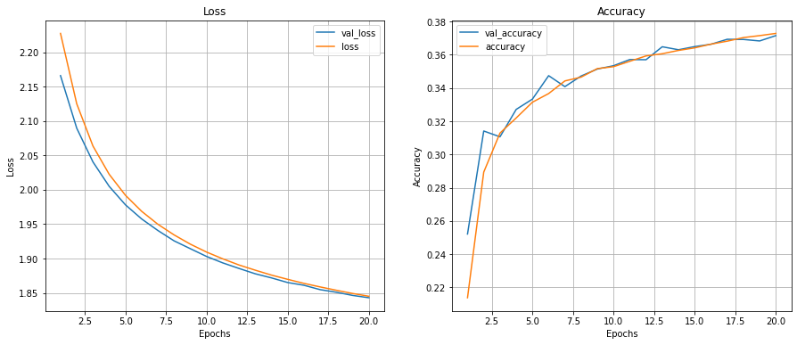

```python
epochs = range(1, len(history.history['val_loss'])+1)
plt.figure(figsize=(15,6))
plt.subplot(121)
plt.title('Loss')
plt.plot(epochs, history.history['val_loss'], label='val_loss')
plt.plot(epochs, history.history['loss'], label='loss')
plt.xlabel('Epochs')
plt.ylabel('Loss')
#plt.ylim([0.5,1.5])
plt.grid()
plt.legend()
plt.subplot(122)
plt.title('Accuracy')
plt.plot(epochs, history.history['val_accuracy'], label='val_accuracy')
plt.plot(epochs, history.history['accuracy'], label='accuracy')
plt.xlabel('Epochs')
plt.ylabel('Accuracy')
#plt.ylim([0,1])
plt.grid()
plt.legend()
plt.show()
```

Les résultats obtenus sont un peu plus performants qu'avec les images en noir et blanc. Avec les mêmes paramètres, on a obtenu un score d'accuracy de 0.37 contre 0.28 dans le premier cas. Les erreurs de la loss décroissent bien quand le nombre d'epochs augmente et pareil, le score d'accuracy augmente quand le nombre d'epochs augmente. Les courbes obtenues sont plutot stables.

On pourra essayer d'augmenter le nombre d'epochs, le batch_size comme précédemment.

```python
# Evaluation du modèle
score = model.evaluate(X_val, Y_val, verbose=1)
print('Test score: %.3f' % score[0])
print('Test accuracy: %.3f' % score[1])
```

```
Test score: 1.843
Test accuracy: 0.371
```

### Avec epochs = 40 et batch_size = 64

```python
model = Sequential([
    Dense(10),
    Activation('softmax'),
])
```

```python
opt = tf.keras.optimizers.Adam(learning_rate=0.001)

model.compile(loss='categorical_crossentropy',
              optimizer=opt,
              metrics=['accuracy'])
```

```python
history = model.fit(
          X_train, Y_train,
          validation_data=(X_val, Y_val),
          epochs=40, batch_size=64,
          verbose=1)
```

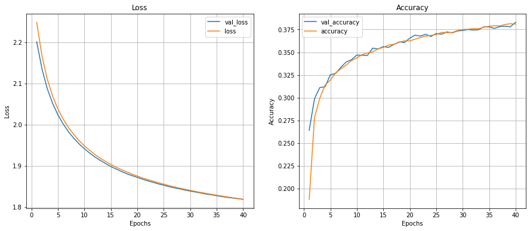

```python
epochs = range(1, len(history.history['val_loss'])+1)
plt.figure(figsize=(15,6))
plt.subplot(121)
plt.title('Loss')
plt.plot(epochs, history.history['val_loss'], label='val_loss')
plt.plot(epochs, history.history['loss'], label='loss')
plt.xlabel('Epochs')
plt.ylabel('Loss')
#plt.ylim([0.5,1.5])
plt.grid()
plt.legend()
plt.subplot(122)
plt.title('Accuracy')
plt.plot(epochs, history.history['val_accuracy'], label='val_accuracy')
plt.plot(epochs, history.history['accuracy'], label='accuracy')
plt.xlabel('Epochs')
plt.ylabel('Accuracy')
#plt.ylim([0,1])
plt.grid()
plt.legend()
plt.show()
```

```python
# Evaluation du modèle
score = model.evaluate(X_val, Y_val, verbose=1)
print('Test score: %.3f' % score[0])
print('Test accuracy: %.3f' % score[1])
```

```
Test score: 1.819
Test accuracy: 0.383
```

Les résultats obtenus sont un peu plus performants et on a gagné en convergence.

## Deuxième modèle : Fully-connected (plusieurs couches) + Image en couleur

### Avec epochs = 20 et batch_size = 32

```python
# Ajoute des couches de Dropout pour protéger le modèle du sur-apprentissage sur le data train
Pkeep=0.25
modelDeepFC = Sequential([
    Dense(256, input_shape=(3072,)),
    Activation('relu'),

    Dropout(Pkeep),

    Dense(128),
    Activation('relu'),

    Dropout(Pkeep),

    Dense(10),
    Activation('softmax'),
])
```

```python
# Ajout d'un learning_rate
opt = tf.keras.optimizers.Adam(learning_rate=0.001)

modelDeepFC.compile(loss='categorical_crossentropy',
              optimizer=opt,
              metrics=['accuracy'])

history = modelDeepFC.fit(X_train, Y_train,
          validation_data=(X_val, Y_val),
          epochs=20, batch_size=32,
          verbose=1)
```

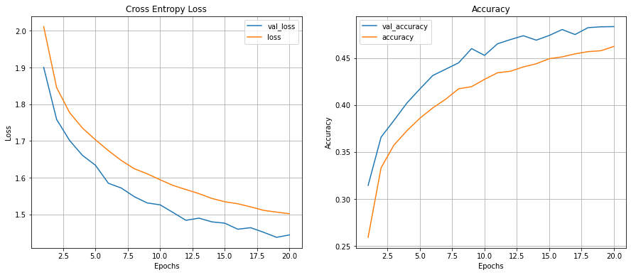

```python
epochs = range(1, len(history.history['val_loss'])+1)
plt.figure(figsize=(15,6))
plt.subplot(121)
plt.title('Cross Entropy Loss')
plt.plot(epochs, history.history['val_loss'], label='val_loss')
plt.plot(epochs, history.history['loss'], label='loss')
plt.xlabel('Epochs')
plt.ylabel('Loss')
#plt.ylim([0.5,1.5])
plt.grid()
plt.legend()
plt.subplot(122)
plt.title('Accuracy')
plt.plot(epochs, history.history['val_accuracy'], label='val_accuracy')
plt.plot(epochs, history.history['accuracy'], label='accuracy')
plt.xlabel('Epochs')
plt.ylabel('Accuracy')
#plt.ylim([0,1])
plt.grid()
plt.legend()
plt.show()
```

```python
# Evaluation du modèle sur le data test
score = modelDeepFC.evaluate(X_val, Y_val)
print('Test score: %.3f' % score[0])
print('Test accuracy: %.3f' % score[1])
```

```
Test score: 1.444
Test accuracy: 0.483
```

On pourra augmenter le nombre de epochs.

### Avec epochs = 40 et batch_size = 32

```python
# Ajoute des couches de Dropout pour protéger le modèle du sur-apprentissage sur le data train
Pkeep=0.25
modelDeepFC = Sequential([
    Dense(256, input_shape=(3072,)),
    Activation('relu'),

    Dropout(Pkeep),

    Dense(128),
    Activation('relu'),

    Dropout(Pkeep),

    Dense(10),
    Activation('softmax'),
])
```

```python
# Ajout d'un learning_rate
opt = tf.keras.optimizers.Adam(learning_rate=0.001)

modelDeepFC.compile(loss='categorical_crossentropy',
              optimizer=opt,
              metrics=['accuracy'])

history = modelDeepFC.fit(X_train, Y_train,
          validation_data=(X_val, Y_val),
          epochs=40, batch_size=32,
          verbose=1)
```

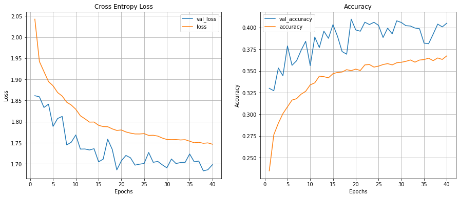

```python
epochs = range(1, len(history.history['val_loss'])+1)
plt.figure(figsize=(15,6))
plt.subplot(121)
plt.title('Cross Entropy Loss')
plt.plot(epochs, history.history['val_loss'], label='val_loss')
plt.plot(epochs, history.history['loss'], label='loss')
plt.xlabel('Epochs')
plt.ylabel('Loss')
#plt.ylim([0.5,1.5])
plt.grid()
plt.legend()
plt.subplot(122)
plt.title('Accuracy')
plt.plot(epochs, history.history['val_accuracy'], label='val_accuracy')
plt.plot(epochs, history.history['accuracy'], label='accuracy')
plt.xlabel('Epochs')
plt.ylabel('Accuracy')
#plt.ylim([0,1])
plt.grid()
plt.legend()
plt.show()
```

```python
# Evaluation du modèle sur le data test
score = modelDeepFC.evaluate(X_val, Y_val)
print('Test score: %.3f' % score[0])
print('Test accuracy: %.3f' % score[1])
```

```
Test score: 1.698
Test accuracy: 0.405
```

Les courbes ne sont pas stables, on va augmenter le batch_size.

### Avec epochs = 40 et batch_size = 64

```python
# Ajoute des couches de Dropout pour protéger le modèle du sur-apprentissage sur le data train
Pkeep=0.25
modelDeepFC = Sequential([
    Dense(256, input_shape=(3072,)),
    Activation('relu'),

    Dropout(Pkeep),

    Dense(128),
    Activation('relu'),

    Dropout(Pkeep),

    Dense(10),
    Activation('softmax'),
])
```

```python
# Ajout d'un learning_rate
opt = tf.keras.optimizers.Adam(learning_rate=0.001)

modelDeepFC.compile(loss='categorical_crossentropy',
              optimizer=opt,
              metrics=['accuracy'])

history = modelDeepFC.fit(X_train, Y_train,
          validation_data=(X_val, Y_val),
          epochs=40, batch_size=64,
          verbose=1)
```

[figure not shown]

```python
epochs = range(1, len(history.history['val_loss'])+1)
plt.figure(figsize=(15,6))
plt.subplot(121)
plt.title('Cross Entropy Loss')
plt.plot(epochs, history.history['val_loss'], label='val_loss')
plt.plot(epochs, history.history['loss'], label='loss')
plt.xlabel('Epochs')
plt.ylabel('Loss')
#plt.ylim([0.5,1.5])
plt.grid()
plt.legend()
plt.subplot(122)
plt.title('Accuracy')
plt.plot(epochs, history.history['val_accuracy'], label='val_accuracy')
plt.plot(epochs, history.history['accuracy'], label='accuracy')
plt.xlabel('Epochs')
plt.ylabel('Accuracy')
#plt.ylim([0,1])
plt.grid()
plt.legend()
plt.show()
```

```python
# Evaluation du modèle sur le data test
score = modelDeepFC.evaluate(X_val, Y_val)
print('Test score: %.3f' % score[0])
print('Test accuracy: %.3f' % score[1])
```

```
Test score: 1.329
Test accuracy: 0.526
```

On obtient de meilleurs résultats en augmentant le batch_size que précédemment.

Pour essayer on peut augmenter le nombre d'epochs pour voir si cela conduit à une amélioration.

### Avec epochs = 100 et batch_size = 64

```python
# Ajoute des couches de Dropout pour protéger le modèle du sur-apprentissage sur le data train
Pkeep=0.25
modelDeepFC = Sequential([
    Dense(256, input_shape=(3072,)),
    Activation('relu'),

    Dropout(Pkeep),

    Dense(128),
    Activation('relu'),

    Dropout(Pkeep),

    Dense(10),
    Activation('softmax'),
])
```

```python
# Ajout d'un learning_rate
opt = tf.keras.optimizers.Adam(learning_rate=0.001)

modelDeepFC.compile(loss='categorical_crossentropy',
              optimizer=opt,
              metrics=['accuracy'])

history = modelDeepFC.fit(X_train, Y_train,
          validation_data=(X_val, Y_val),
          epochs=100, batch_size=64,
          verbose=1)
```

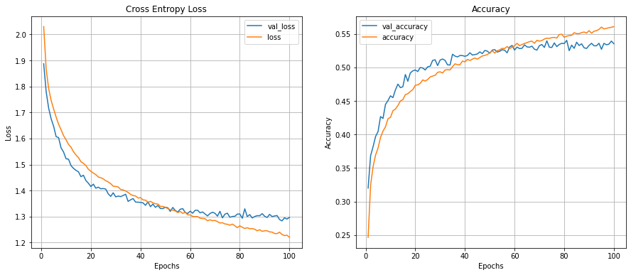

```python
epochs = range(1, len(history.history['val_loss'])+1)
plt.figure(figsize=(15,6))
plt.subplot(121)
plt.title('Cross Entropy Loss')
plt.plot(epochs, history.history['val_loss'], label='val_loss')
plt.plot(epochs, history.history['loss'], label='loss')
plt.xlabel('Epochs')
plt.ylabel('Loss')
#plt.ylim([0.5,1.5])
plt.grid()
plt.legend()
plt.subplot(122)
plt.title('Accuracy')
plt.plot(epochs, history.history['val_accuracy'], label='val_accuracy')
plt.plot(epochs, history.history['accuracy'], label='accuracy')
plt.xlabel('Epochs')
plt.ylabel('Accuracy')
#plt.ylim([0,1])
plt.grid()
plt.legend()
plt.show()
```

```python
# Evaluation du modèle sur le data test
score = modelDeepFC.evaluate(X_val, Y_val)
print('Test score: %.3f' % score[0])
print('Test accuracy: %.3f' % score[1])
```

```
Test score: 1.297
Test accuracy: 0.535
```

Il est clair qu'on observe du sur-apprentissage, il y a un nombre trop élevé d'epochs, on pourra alors diminuer ce paramètre afin d'optimiser les résultats.

### Avec epochs = 70 et batch_size = 64

```python
# Ajoute des couches de Dropout pour protéger le modèle du sur-apprentissage sur le data train
Pkeep=0.25
modelDeepFC = Sequential([
    Dense(256, input_shape=(3072,)),
    Activation('relu'),

    Dropout(Pkeep),

    Dense(128),
    Activation('relu'),

    Dropout(Pkeep),

    Dense(10),
    Activation('softmax'),
])
```

```python
# Ajout d'un learning_rate
opt = tf.keras.optimizers.Adam(learning_rate=0.001)

modelDeepFC.compile(loss='categorical_crossentropy',
              optimizer=opt,
              metrics=['accuracy'])

history = modelDeepFC.fit(X_train, Y_train,
          validation_data=(X_val, Y_val),
          epochs=70, batch_size=64,
          verbose=1)
```

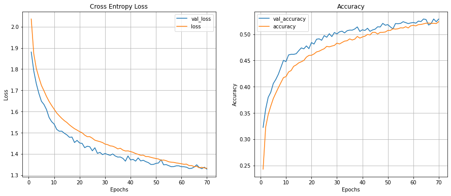

```python
epochs = range(1, len(history.history['val_loss'])+1)
plt.figure(figsize=(15,6))
plt.subplot(121)
plt.title('Cross Entropy Loss')
plt.plot(epochs, history.history['val_loss'], label='val_loss')
plt.plot(epochs, history.history['loss'], label='loss')
plt.xlabel('Epochs')
plt.ylabel('Loss')
#plt.ylim([0.5,1.5])
plt.grid()
plt.legend()
plt.subplot(122)
plt.title('Accuracy')
plt.plot(epochs, history.history['val_accuracy'], label='val_accuracy')
plt.plot(epochs, history.history['accuracy'], label='accuracy')
plt.xlabel('Epochs')
plt.ylabel('Accuracy')
#plt.ylim([0,1])
plt.grid()
plt.legend()
plt.show()
```

```python
# Evaluation du modèle sur le data test
score = modelDeepFC.evaluate(X_val, Y_val)
print('Test score: %.3f' % score[0])
print('Test accuracy: %.3f' % score[1])
```

```
Test score: 1.328
Test accuracy: 0.529
```

On obtient des résultats satisfaisants en termes de scores, de stabilité des courbes et de convergence. C'est l'un de nos meilleurs modèles.

On pourrait essayer d'augmenter le nombre de couches du réseau en adaptant le pas d'apprentissage.

# CNN + Image en couleur

### Chargement des données + Pré-traitement

```python
from keras.datasets import cifar10
(X_train, y_train), (X_test, y_test) = cifar10.load_data()
```

```
Downloading data from https://www.cs.toronto.edu/~kriz/cifar-10-python.tar.gz
```

```python
print('Train: X = %s, y =% s' % (X_train.shape, y_train.shape))
print('Test: X = %s, y = %s' % (X_test.shape, y_test.shape))
```

```
Train: X = (50000, 32, 32, 3), y =(50000, 1)
Test: X = (10000, 32, 32, 3), y = (10000, 1)
```

```python
# Conversion des images en niveau de gris
X_train_grey = color.rgb2gray(X_train)
X_test_grey = color.rgb2gray(X_test)
```

```python
# Redimentionner les images + Convertion des entiers en décimaux
X_train = X_train.reshape(X_train.shape[0], 32, 32, 3).astype('float32')
X_test = X_test.reshape(X_test.shape[0], 32, 32, 3).astype('float32')

X_train_grey = X_train_grey.reshape(X_train_grey.shape[0], 32, 32, 1).astype('float32')
X_test_grey = X_test_grey.reshape(X_test_grey.shape[0], 32, 32, 1).astype('float32')

# Normaliser les entrées (convertir de 0-255 en 0-1)
X_train /= 255
X_test /= 255

X_train_grey /= 255
X_test_grey /= 255
```

```python
# Encodage des sorties des échantillons de données (train et validation) One Hot Encoding
Y_train = to_categorical(y_train, num_classes=10)
Y_test = to_categorical(y_test, num_classes=10)
```

### Premier modèle :

On augmente la profondeur du réseau de couches de convolution pour extraire les features des images.

```python
modelCNN = Sequential([
    # Convolution Layer 1
    Conv2D(32, (3, 3), activation='relu', input_shape=(32,32,3)),
    MaxPooling2D(pool_size=(2, 2)),

    # Convolution Layer 2
    Conv2D(64, (3, 3), activation='relu'),
    MaxPooling2D(pool_size=(2, 2)),

    # Convolution Layer 3
    Conv2D(128, (3, 3), activation='relu'),
    MaxPooling2D(pool_size=(2, 2)),

    Flatten(),

    # Fully Connected Layer 4
    Dense(128),
    Activation('relu'),

    Dense(10),
    Activation('softmax'),
])
modelCNN.summary()
```

```
Model: "sequential_5"
_________________________________________________________________
 Layer (type)                Output Shape              Param #
=================================================================
 conv2d_15 (Conv2D)          (None, 30, 30, 32)        896

 max_pooling2d_11 (MaxPoolin  (None, 15, 15, 32)       0
 g2D)

 conv2d_16 (Conv2D)          (None, 13, 13, 64)        18496

 max_pooling2d_12 (MaxPoolin  (None, 6, 6, 64)         0
 g2D)

 conv2d_17 (Conv2D)          (None, 4, 4, 128)         73856

 max_pooling2d_13 (MaxPoolin  (None, 2, 2, 128)        0
 g2D)

 flatten_5 (Flatten)         (None, 512)               0

 dense_10 (Dense)            (None, 128)               65664

 activation_10 (Activation)  (None, 128)               0

 dense_11 (Dense)            (None, 10)                1290

 activation_11 (Activation)  (None, 10)                0

=================================================================
Total params: 160,202
Trainable params: 160,202
Non-trainable params: 0
_________________________________________________________________
```

```python
modelCNN.compile(loss='categorical_crossentropy',
              optimizer= tf.keras.optimizers.Adam(learning_rate=0.001),
              metrics=['accuracy'])

history = modelCNN.fit(X_train, Y_train,
          validation_data=(X_test, Y_test),
          epochs=20, batch_size=32,
          verbose=1)
```

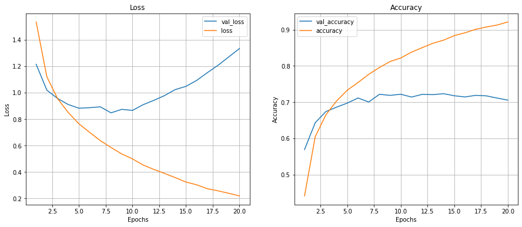

```python
epochs = range(1, len(history.history['val_loss'])+1)
plt.figure(figsize=(15,6))
plt.subplot(121)
plt.title('Loss')
plt.plot(epochs, history.history['val_loss'], label='val_loss')
plt.plot(epochs, history.history['loss'], label='loss')
#plt.ylim([0.5,1.5])
plt.grid()
plt.xlabel('Epochs')
plt.ylabel('Loss')
plt.legend()
plt.subplot(122)
plt.title('Accuracy')
plt.plot(epochs, history.history['val_accuracy'], label='val_accuracy')
plt.plot(epochs, history.history['accuracy'], label='accuracy')
#plt.ylim([0,1])
plt.xlabel('Epochs')
plt.ylabel('Accuracy')
plt.grid()
plt.legend()
```

```python
score = modelCNN.evaluate(X_test,Y_test)
print('Test score: %.3f' % score[0])
print('Test accuracy: %.3f' % score[1])
```

```
Test score: 1.333
Test accuracy: 0.706
```

Les courbes montrent très clairement le sur-apprentissage. Mais les scores sont meilleurs avec le CNN que seulement les couches de Fully-connected.

29 min temps d'exécution

On peut ajuster le modèle soit en ajoutant des couches de Droupout comme on a pu voir précédemment, mais aussi, on peut choisir de réduire le nombre d'epochs ou de réduire le pas d'apprentissage (learning rate).

On va tester toutes ces options pour voir quel est le modèle qui donne des meilleurs résultats.

### Modèle : Ajout de couches de Droupout

```python
modelCNN = Sequential([
    # Convolution Layer 1
    Conv2D(32, (3, 3), activation='relu', input_shape=(32,32,3)),
    MaxPooling2D(pool_size=(2, 2)),
    Dropout(0.2),

    # Convolution Layer 2
    Conv2D(64, (3, 3), activation='relu'),
    MaxPooling2D(pool_size=(2, 2)),
    Dropout(0.2),

    # Convolution Layer 3
    Conv2D(128, (3, 3), activation='relu'),
    MaxPooling2D(pool_size=(2, 2)),
    Dropout(0.2),

    Flatten(),

    # Fully Connected Layer 4
    Dense(128),
    Activation('relu'),
    Dropout(0.2),

    Dense(10),
    Activation('softmax'),
])
modelCNN.summary()
```

```
Model: "sequential"
_________________________________________________________________
 Layer (type)                Output Shape              Param #
=================================================================
 conv2d (Conv2D)             (None, 30, 30, 32)        896

 max_pooling2d (MaxPooling2D  (None, 15, 15, 32)       0
 )

 dropout (Dropout)           (None, 15, 15, 32)        0

 conv2d_1 (Conv2D)           (None, 13, 13, 64)        18496

 max_pooling2d_1 (MaxPooling  (None, 6, 6, 64)         0
 2D)

 dropout_1 (Dropout)         (None, 6, 6, 64)          0

 conv2d_2 (Conv2D)           (None, 4, 4, 128)         73856

 max_pooling2d_2 (MaxPooling  (None, 2, 2, 128)        0
 2D)

 dropout_2 (Dropout)         (None, 2, 2, 128)         0

 flatten (Flatten)           (None, 512)               0

 dense (Dense)               (None, 128)               65664

 activation (Activation)     (None, 128)               0

 dropout_3 (Dropout)         (None, 128)               0

 dense_1 (Dense)             (None, 10)                1290

 activation_1 (Activation)   (None, 10)                0

=================================================================
Total params: 160,202
Trainable params: 160,202
Non-trainable params: 0
_________________________________________________________________
```

```python
modelCNN.compile(loss='categorical_crossentropy',
              optimizer= tf.keras.optimizers.Adam(learning_rate=0.001),
              metrics=['accuracy'])

history = modelCNN.fit(X_train, Y_train,
          validation_data=(X_test, Y_test),
          epochs=20, batch_size=32,
          verbose=1)
```

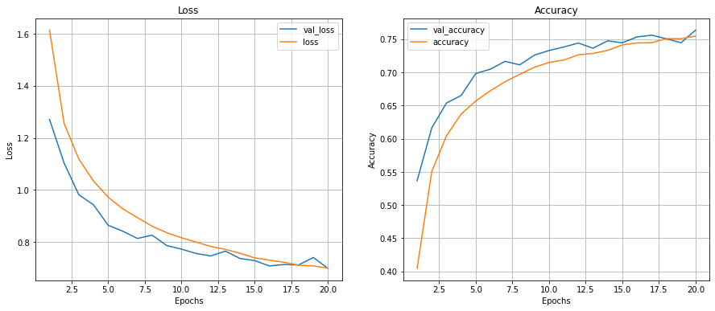

```python
epochs = range(1, len(history.history['val_loss'])+1)
plt.figure(figsize=(15,6))
plt.subplot(121)
plt.title('Loss')
plt.plot(epochs, history.history['val_loss'], label='val_loss')
plt.plot(epochs, history.history['loss'], label='loss')
#plt.ylim([0.5,1.5])
plt.grid()
plt.xlabel('Epochs')
plt.ylabel('Loss')
plt.legend()
plt.subplot(122)
plt.title('Accuracy')
plt.plot(epochs, history.history['val_accuracy'], label='val_accuracy')
plt.plot(epochs, history.history['accuracy'], label='accuracy')
#plt.ylim([0,1])
plt.xlabel('Epochs')
plt.ylabel('Accuracy')
plt.grid()
plt.legend()
```

```python
score = modelCNN.evaluate(X_test,Y_test)
print('Test score: %.3f' % score[0])
print('Test accuracy: %.3f' % score[1])
```

```
Test score: 0.698
Test accuracy: 0.764
```

On obtient de meilleurs résultats, les courbes sont stables. En revanche le temps de calcul est long, environ 33 minutes.

### Prédiction

```python
predictions = modelCNN.predict(X_test) # Prediction of classes
classes = np.argmax(predictions, axis=1)
```

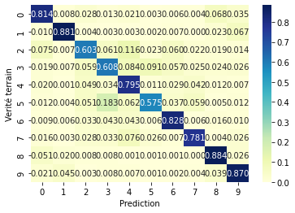

```python
from sklearn import metrics
import seaborn as sns
import numpy.matlib
matrix = metrics.confusion_matrix(Y_test.argmax(axis=1), classes)
matrix_normalized = (matrix/np.matlib.repmat(np.sum(matrix,axis=1).reshape((1,10)),10,1)) # selon axe 0 : combien d'objets classés en tant que i viennent effectivement de i # selon axe 1 : comment ont été classées les différentes classes
sns.heatmap(matrix_normalized, annot=True, cmap="YlGnBu", fmt='.3f')
plt.xlabel('Prediction')
plt.ylabel('Verité terrain')
plt.show()
```

```python
modelCNN = Sequential([
    # Convolution Layer 1
    Conv2D(32, (3, 3), activation='relu', input_shape=(32,32,3)),
    MaxPooling2D(pool_size=(2, 2)),

    # Convolution Layer 2
    Conv2D(64, (3, 3), activation='relu'),
    MaxPooling2D(pool_size=(2, 2)),

    # Convolution Layer 3
    Conv2D(128, (3, 3), activation='relu'),
    MaxPooling2D(pool_size=(2, 2)),

    Flatten(),

    # Fully Connected Layer 4
    Dense(128),
    Activation('relu'),

    Dense(10),
    Activation('softmax'),
])
modelCNN.summary()
```

```
Model: "sequential_8"
_________________________________________________________________
 Layer (type)                Output Shape              Param #
=================================================================
 conv2d_24 (Conv2D)          (None, 30, 30, 32)        896

 max_pooling2d_20 (MaxPoolin  (None, 15, 15, 32)       0
 g2D)

 conv2d_25 (Conv2D)          (None, 13, 13, 64)        18496

 max_pooling2d_21 (MaxPoolin  (None, 6, 6, 64)         0
 g2D)

 conv2d_26 (Conv2D)          (None, 4, 4, 128)         73856

 max_pooling2d_22 (MaxPoolin  (None, 2, 2, 128)        0
 g2D)

 flatten_8 (Flatten)         (None, 512)               0

 dense_16 (Dense)            (None, 128)               65664

 activation_16 (Activation)  (None, 128)               0

 dense_17 (Dense)            (None, 10)                1290

 activation_17 (Activation)  (None, 10)                0

=================================================================
Total params: 160,202
Trainable params: 160,202
Non-trainable params: 0
_________________________________________________________________
```

```python
modelCNN.compile(loss='categorical_crossentropy',
              optimizer= tf.keras.optimizers.Adam(learning_rate=0.01),
              metrics=['accuracy'])

history = modelCNN.fit(X_train, Y_train,
          validation_data=(X_test, Y_test),
          epochs=20, batch_size=32,
          verbose=1)
```

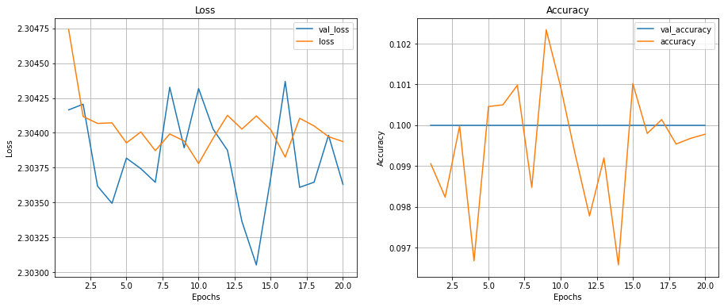

```python
epochs = range(1, len(history.history['val_loss'])+1)
plt.figure(figsize=(15,6))
plt.subplot(121)
plt.title('Loss')
plt.plot(epochs, history.history['val_loss'], label='val_loss')
plt.plot(epochs, history.history['loss'], label='loss')
#plt.ylim([0.5,1.5])
plt.grid()
plt.xlabel('Epochs')
plt.ylabel('Loss')
plt.legend()
plt.subplot(122)
plt.title('Accuracy')
plt.plot(epochs, history.history['val_accuracy'], label='val_accuracy')
plt.plot(epochs, history.history['accuracy'], label='accuracy')
#plt.ylim([0,1])
plt.xlabel('Epochs')
plt.ylabel('Accuracy')
plt.grid()
plt.legend()
```

```python
score = modelCNN.evaluate(X_test,Y_test)
print('Test score: %.3f' % score[0])
print('Test accuracy: %.3f' % score[1])
```

```
Test score: 2.304
Test accuracy: 0.100
```

### Modèle : Diminuer le nombre d'epochs

```python
modelCNN = Sequential([
    # Convolution Layer 1
    Conv2D(32, (3, 3), activation='relu', input_shape=(32,32,3)), # 32 different 3x3 kernels -- so 32 feature maps
    MaxPooling2D(pool_size=(2, 2)), # Pool the max values over a 2x2 kernel

    # Convolution Layer 2
    Conv2D(64, (3, 3), activation='relu'), # 64 different 3x3 kernels
    MaxPooling2D(pool_size=(2, 2)),

    # Convolution Layer 3
    Conv2D(128, (3, 3), activation='relu'), # 128 different 3x3 kernels
    MaxPooling2D(pool_size=(2, 2)),

    Flatten(), # Flatten final 7x7x128 output matrix into a 1024-length vector

    # Fully Connected Layer 4
    Dense(128),
    Activation('relu'),

    Dense(10),
    Activation('softmax'),
])
modelCNN.summary()
```

```
Model: "sequential_9"
_________________________________________________________________
 Layer (type)                Output Shape              Param #
=================================================================
 conv2d_27 (Conv2D)          (None, 30, 30, 32)        896

 max_pooling2d_23 (MaxPoolin  (None, 15, 15, 32)       0
 g2D)

 conv2d_28 (Conv2D)          (None, 13, 13, 64)        18496

 max_pooling2d_24 (MaxPoolin  (None, 6, 6, 64)         0
 g2D)

 conv2d_29 (Conv2D)          (None, 4, 4, 128)         73856

 max_pooling2d_25 (MaxPoolin  (None, 2, 2, 128)        0
 g2D)

 flatten_9 (Flatten)         (None, 512)               0

 dense_18 (Dense)            (None, 128)               65664

 activation_18 (Activation)  (None, 128)               0

 dense_19 (Dense)            (None, 10)                1290

 activation_19 (Activation)  (None, 10)                0

=================================================================
Total params: 160,202
Trainable params: 160,202
Non-trainable params: 0
_________________________________________________________________
```

```python
modelCNN.compile(loss='categorical_crossentropy',
              optimizer= tf.keras.optimizers.Adam(learning_rate=0.001),
              metrics=['accuracy'])

history = modelCNN.fit(X_train, Y_train,
          validation_data=(X_test, Y_test),
          epochs=10, batch_size=32,
          verbose=1)
```

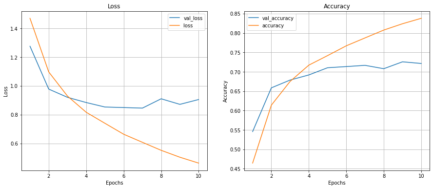

```python
epochs = range(1, len(history.history['val_loss'])+1)
plt.figure(figsize=(15,6))
plt.subplot(121)
plt.title('Loss')
plt.plot(epochs, history.history['val_loss'], label='val_loss')
plt.plot(epochs, history.history['loss'], label='loss')
#plt.ylim([0.5,1.5])
plt.grid()
plt.xlabel('Epochs')
plt.ylabel('Loss')
plt.legend()
plt.subplot(122)
plt.title('Accuracy')
plt.plot(epochs, history.history['val_accuracy'], label='val_accuracy')
plt.plot(epochs, history.history['accuracy'], label='accuracy')
#plt.ylim([0,1])
plt.xlabel('Epochs')
plt.ylabel('Accuracy')
plt.grid()
plt.legend()
```

```python
score = modelCNN.evaluate(X_test,Y_test)
print('Test score: %.3f' % score[0])
print('Test accuracy: %.3f' % score[1])
```

```
Test score: 0.905
Test accuracy: 0.721
```

On a obtenu de très bons résultats (72% d'accuracy).

### Conclusion

Le modèle qui nous a donner de meilleurs résultats est celui où on ajoute des couches de Droupout.

# CNN + Images en noir et blanc

### Premier modèle :

```python
modelCNN = Sequential([
    # Convolution Layer 1
    Conv2D(32, (3, 3), activation='relu', input_shape=(32,32,1)),
    MaxPooling2D(pool_size=(2, 2)),

    # Convolution Layer 2
    Conv2D(64, (3, 3), activation='relu'),
    MaxPooling2D(pool_size=(2, 2)),

    # Convolution Layer 3
    Conv2D(128, (3, 3), activation='relu'),
    MaxPooling2D(pool_size=(2, 2)),

    Flatten(),

    # Fully Connected Layer 4
    Dense(128),
    Activation('relu'),

    Dense(10),
    Activation('softmax'),
])
modelCNN.summary()
```

```
Model: "sequential_2"
_________________________________________________________________
 Layer (type)                Output Shape              Param #
=================================================================
 conv2d_6 (Conv2D)           (None, 30, 30, 32)        320

 max_pooling2d_6 (MaxPooling  (None, 15, 15, 32)       0
 2D)

 conv2d_7 (Conv2D)           (None, 13, 13, 64)        18496

 max_pooling2d_7 (MaxPooling  (None, 6, 6, 64)         0
 2D)

 conv2d_8 (Conv2D)           (None, 4, 4, 128)         73856

 max_pooling2d_8 (MaxPooling  (None, 2, 2, 128)        0
 2D)

 flatten_2 (Flatten)         (None, 512)               0

 dense_4 (Dense)             (None, 128)               65664

 activation_4 (Activation)   (None, 128)               0

 dense_5 (Dense)             (None, 10)                1290

 activation_5 (Activation)   (None, 10)                0

=================================================================
Total params: 159,626
Trainable params: 159,626
Non-trainable params: 0
_________________________________________________________________
```

```python
modelCNN.compile(loss='categorical_crossentropy',
              optimizer= tf.keras.optimizers.Adam(learning_rate=0.001),
              metrics=['accuracy'])

history = modelCNN.fit(X_train_grey, Y_train,
          validation_data=(X_test_grey, Y_test),
          epochs=20, batch_size=32,
          verbose=1)
```

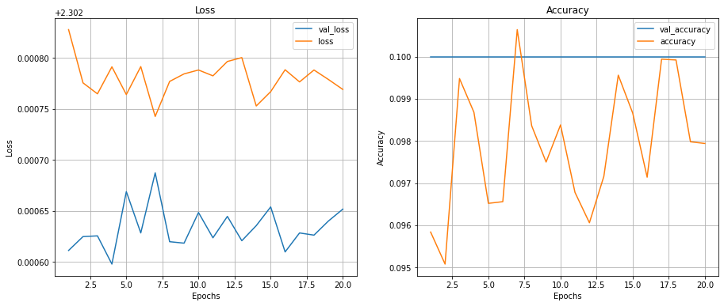

```python
epochs = range(1, len(history.history['val_loss'])+1)
plt.figure(figsize=(15,6))
plt.subplot(121)
plt.title('Loss')
plt.plot(epochs, history.history['val_loss'], label='val_loss')
plt.plot(epochs, history.history['loss'], label='loss')
#plt.ylim([0.5,1.5])
plt.grid()
plt.xlabel('Epochs')
plt.ylabel('Loss')
plt.legend()
plt.subplot(122)
plt.title('Accuracy')
plt.plot(epochs, history.history['val_accuracy'], label='val_accuracy')
plt.plot(epochs, history.history['accuracy'], label='accuracy')
#plt.ylim([0,1])
plt.xlabel('Epochs')
plt.ylabel('Accuracy')
plt.grid()
plt.legend()
```

```python
score = modelCNN.evaluate(X_test_grey,Y_test)
print('Test score: %.3f' % score[0])
print('Test accuracy: %.3f' % score[1])
```

```
Test score: 2.303
Test accuracy: 0.100
```

Le modèle est pas du tout adapté. On peut essayer de diminuer le pas d'apprentissage pour que le modèle converge.

### Modèle : Ajout d'une couche de Droupout + Diminution du learning_rate.

```python
modelCNN = Sequential([
    # Convolution Layer 1
    Conv2D(32, (3, 3), activation='relu', input_shape=(32,32,1)),
    MaxPooling2D(pool_size=(2, 2)),

    # Convolution Layer 2
    Conv2D(64, (3, 3), activation='relu'),
    MaxPooling2D(pool_size=(2, 2)),

    # Convolution Layer 3
    Conv2D(128, (3, 3), activation='relu'),
    MaxPooling2D(pool_size=(2, 2)),
    Dropout(0.2),

    Flatten(),

    # Fully Connected Layer 4
    Dense(128),
    Activation('relu'),
    Dropout(0.2),

    Dense(10),
    Activation('softmax'),
])
modelCNN.summary()
```

```
Model: "sequential_11"
_________________________________________________________________
 Layer (type)                Output Shape              Param #
=================================================================
 conv2d_33 (Conv2D)          (None, 30, 30, 32)        320

 max_pooling2d_33 (MaxPoolin  (None, 15, 15, 32)       0
 g2D)

 conv2d_34 (Conv2D)          (None, 13, 13, 64)        18496

 max_pooling2d_34 (MaxPoolin  (None, 6, 6, 64)         0
 g2D)

 conv2d_35 (Conv2D)          (None, 4, 4, 128)         73856

 max_pooling2d_35 (MaxPoolin  (None, 2, 2, 128)        0
 g2D)

 dropout_26 (Dropout)        (None, 2, 2, 128)         0

 flatten_11 (Flatten)        (None, 512)               0

 dense_22 (Dense)            (None, 128)               65664

 activation_22 (Activation)  (None, 128)               0

 dropout_27 (Dropout)        (None, 128)               0

 dense_23 (Dense)            (None, 10)                1290

 activation_23 (Activation)  (None, 10)                0

=================================================================
Total params: 159,626
Trainable params: 159,626
Non-trainable params: 0
_________________________________________________________________
```

```python
modelCNN.compile(loss='categorical_crossentropy',
              optimizer= tf.keras.optimizers.Adam(learning_rate=0.0001),
              metrics=['accuracy'])

history = modelCNN.fit(X_train_grey, Y_train,
          validation_data=(X_test_grey, Y_test),
          epochs=20, batch_size=32,
          verbose=1)
```

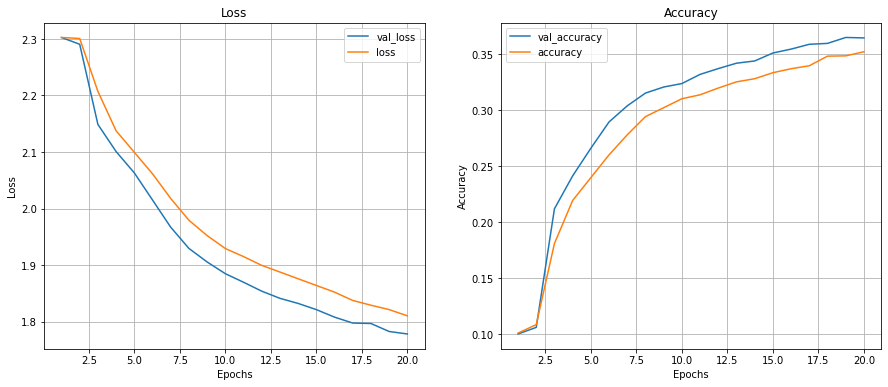

```python
epochs = range(1, len(history.history['val_loss'])+1)
plt.figure(figsize=(15,6))
plt.subplot(121)
plt.title('Loss')
plt.plot(epochs, history.history['val_loss'], label='val_loss')
plt.plot(epochs, history.history['loss'], label='loss')
#plt.ylim([0.5,1.5])
plt.grid()
plt.xlabel('Epochs')
plt.ylabel('Loss')
plt.legend()
plt.subplot(122)
plt.title('Accuracy')
plt.plot(epochs, history.history['val_accuracy'], label='val_accuracy')
plt.plot(epochs, history.history['accuracy'], label='accuracy')
#plt.ylim([0,1])
plt.xlabel('Epochs')
plt.ylabel('Accuracy')
plt.grid()
plt.legend()
```

```python
score = modelCNN.evaluate(X_test_grey,Y_test)
print('Test score: %.3f' % score[0])
print('Test accuracy: %.3f' % score[1])
```

```
Test score: 1.778
Test accuracy: 0.365
```

### Modèle : Ajustement des paramètres : epoch et batch_size

```python
modelCNN = Sequential([
    # Convolution Layer 1
    Conv2D(32, (3, 3), activation='relu', input_shape=(32,32,1)),
    MaxPooling2D(pool_size=(2, 2)),

    # Convolution Layer 2
    Conv2D(64, (3, 3), activation='relu'),
    MaxPooling2D(pool_size=(2, 2)),

    # Convolution Layer 3
    Conv2D(128, (3, 3), activation='relu'),
    MaxPooling2D(pool_size=(2, 2)),
    Dropout(0.2),

    Flatten(),

    # Fully Connected Layer 4
    Dense(128),
    Activation('relu'),
    Dropout(0.2),

    Dense(10),
    Activation('softmax'),
])
modelCNN.summary()
```

```
Model: "sequential_12"
_________________________________________________________________
 Layer (type)                Output Shape              Param #
=================================================================
 conv2d_36 (Conv2D)          (None, 30, 30, 32)        320

 max_pooling2d_36 (MaxPoolin  (None, 15, 15, 32)       0
 g2D)

 conv2d_37 (Conv2D)          (None, 13, 13, 64)        18496

 max_pooling2d_37 (MaxPoolin  (None, 6, 6, 64)         0
 g2D)

 conv2d_38 (Conv2D)          (None, 4, 4, 128)         73856

 max_pooling2d_38 (MaxPoolin  (None, 2, 2, 128)        0
 g2D)

 dropout_28 (Dropout)        (None, 2, 2, 128)         0

 flatten_12 (Flatten)        (None, 512)               0

 dense_24 (Dense)            (None, 128)               65664

 activation_24 (Activation)  (None, 128)               0

 dropout_29 (Dropout)        (None, 128)               0

 dense_25 (Dense)            (None, 10)                1290

 activation_25 (Activation)  (None, 10)                0

=================================================================
Total params: 159,626
Trainable params: 159,626
Non-trainable params: 0
_________________________________________________________________
```

```python
modelCNN.compile(loss='categorical_crossentropy',
              optimizer= tf.keras.optimizers.Adam(learning_rate=0.0001),
              metrics=['accuracy'])

history = modelCNN.fit(X_train_grey, Y_train,
          validation_data=(X_test_grey, Y_test),
          epochs=40, batch_size=64,
          verbose=1)
```

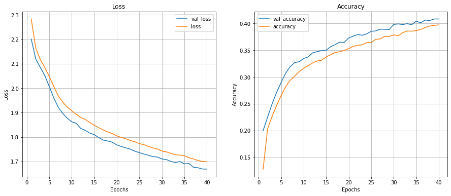

```python
epochs = range(1, len(history.history['val_loss'])+1)
plt.figure(figsize=(15,6))
plt.subplot(121)
plt.title('Loss')
plt.plot(epochs, history.history['val_loss'], label='val_loss')
plt.plot(epochs, history.history['loss'], label='loss')
#plt.ylim([0.5,1.5])
plt.grid()
plt.xlabel('Epochs')
plt.ylabel('Loss')
plt.legend()
plt.subplot(122)
plt.title('Accuracy')
plt.plot(epochs, history.history['val_accuracy'], label='val_accuracy')
plt.plot(epochs, history.history['accuracy'], label='accuracy')
#plt.ylim([0,1])
plt.xlabel('Epochs')
plt.ylabel('Accuracy')
plt.grid()
plt.legend()
```

```python
score = modelCNN.evaluate(X_test_grey,Y_test)
print('Test score: %.3f' % score[0])
print('Test accuracy: %.3f' % score[1])
```

```
Test score: 1.669
Test accuracy: 0.408
```

Résultat satisfaisant pour des images en noir et blanc. Temps de calcul élevé (50min). On préfera pas augmenter les paramètres.

### Prédiction

```python
predictions = modelCNN.predict(X_test_grey) # Prediction of classes
classes = np.argmax(predictions, axis=1)
```

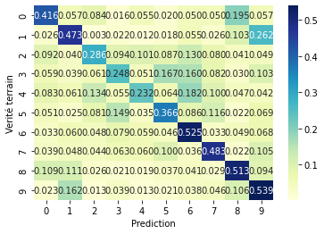

```python
from sklearn import metrics
import seaborn as sns
import numpy.matlib
matrix = metrics.confusion_matrix(Y_test.argmax(axis=1), classes)
matrix_normalized = (matrix/np.matlib.repmat(np.sum(matrix,axis=1).reshape((1,10)),10,1)) # selon axe 0 : combien d'objets classés en tant que i viennent effectivement de i # selon axe 1 : comment ont été classées les différentes classes
sns.heatmap(matrix_normalized, annot=True, cmap="YlGnBu", fmt='.3f')
plt.xlabel('Prediction')
plt.ylabel('Verité terrain')
plt.show()
```

La matrice montre des corrélations significatives entre les images, ce qui explique pourquoi le score d'accuracy par exemple n'est pas très bon. Il est difficile de classer ces images.

On peut peut-être amélioré le modèle en variant le nombre de couches et le nombre de neurones par couches.

# Conclusion :

On peut en conclure qu'en mettant en oeuvre seulement une couche de Fully-connected, on obtient de très mauvais résultats surtout pour les images en noir et blanc. Ceci est cohérent avec le fait que ce sont des images complexes et que la couleur apporte de l'information.

En mettant en oeuvre un réseau de neurones convolutionnels, on a obtenu de très bons résultats.

On pourrait probablement les améliorer en augmentant le nombre d'epochs et le batch_size, c'est un compromis ici à faire étant donné le temps de calcul important.

Par ailleurs, on pourrait chercher à effectuer une data augmentation (copies des images avec de petites modifications sans les déformer). On peut penser aux transformations suivantes : zoom, recadrage de l'image...

En résumé, pour augmenter la convergence, on peut augmenter le batch_size. On peut également jouer sur le nombre d'epochs. C'est deux paramètres sont très liés l'un de l'autre.

Pour éviter le sur-apprentissage, on a pu voir qu'on pouvait diminuer le pas d'apprentissage, diminuer le nombre d'epochs et ajouter des couches de Droupout.